# stock_price_analysis02

# Stock prices analysis

Continue with part 1 …

## Exercise 1

Plot a polygon showing closing prices of stock X for the last 90 trading days.

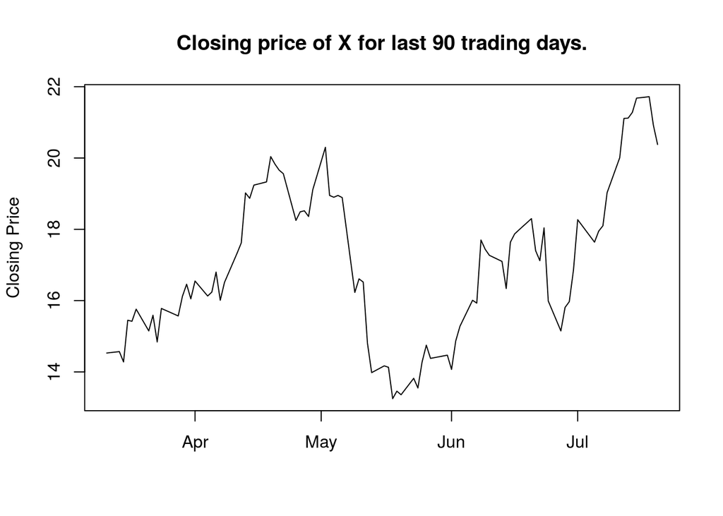

```r
data <- read.csv("http://www.r-exercises.com/wp-content/uploads/2016/07/data.csv")

data.close <- reshape(data[c("Symbol", "Date", "Close")], timevar = "Symbol", idvar = "Date", direction="wide")
colnames(data.close) <- c("Date", as.character(unique(data$Symbol)))
data.close$Date <- as.Date(data.close$Date)
data.close <- data.close[with(data.close, order(Date)), ]

last.90 <- data.close[(NROW(data.close)-90):NROW(data.close), ]
plot(type='l', x=last.90$Date, y=last.90$X, ylab="Closing Price", xlab="", main="Closing price of X for last 90 trading days.")
```

## Exercise 2

Suppose you have equal amounts of each stock in the data frame. Calculate and plot the average daily return of your portfolio. (Tip: daily return on stock is calculated in part 1, exercise 7.)

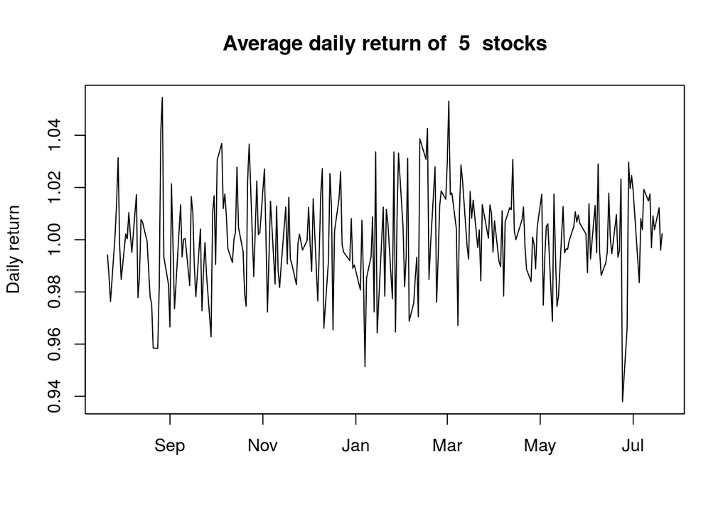

```r
data.return <- data.frame(Date=data.close$Date[-1], sapply(data.close[-1], function(x){
  diff(x) / x[-length(x)] + 1
}))

plot(x=data.return$Date, y=rowMeans(data.return[-1], na.rm = TRUE), type=c('l'), xlab="", ylab="Daily return", main=paste("Average daily return of ", NCOL(data.return)-1, " stocks"))
```

## Exercise 3

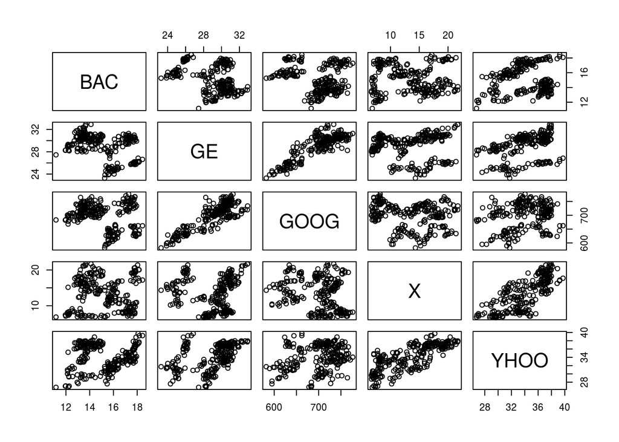

```r
pairs(data.close[-1])
```

## Exercise 4

Fit a linear model of the form Y=a+bX to closing prices of YHOO and plot it on a polygon together with actual closing prices of YHOO.

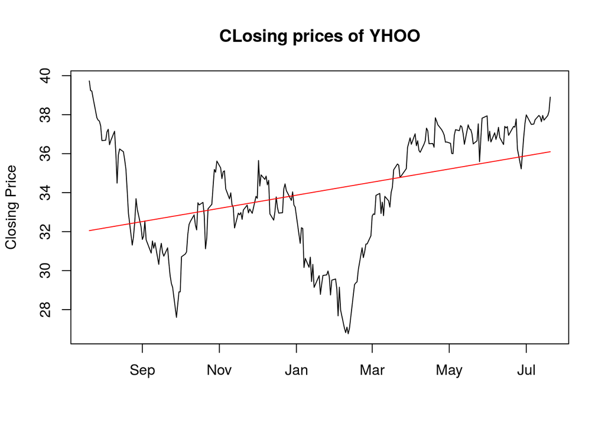

```r
plot(type="l", x=data.close$Date, y=data.close$YHOO, ylab="Closing Price", xlab = "", main="CLosing prices of YHOO")
lines(x=data.close$Date, y=lm(data.close$YHOO~data.close$Date)$fitted.values, col="red")
```

## Exercise 5

How much of the variation in closing prices of GE is explained by the linear model of the form Y=a+bX that fits to daily returns of GE.(Tip: you need to calculate r2.)

```r
summary(lm(data.close$GE~data.close$Date))
```

```
##
## Call:
## lm(formula = data.close$GE ~ data.close$Date)
##
## Residuals:
##     Min      1Q  Median      3Q     Max
## -3.4293 -1.0041 -0.1381  0.9958  2.7175
##
## Coefficients:
##                   Estimate Std. Error t value Pr(>|t|)
## (Intercept)     -2.412e+02  1.410e+01  -17.10   <2e-16 ***
## data.close$Date  1.607e-02  8.387e-04   19.16   <2e-16 ***
## ---
## Signif. codes:  0 '***' 0.001 '**' 0.01 '*' 0.05 '.' 0.1 ' ' 1
##
## Residual standard error: 1.403 on 249 degrees of freedom
##   (2 observations deleted due to missingness)
## Multiple R-squared:  0.5958, Adjusted R-squared:  0.5941
## F-statistic:   367 on 1 and 249 DF,  p-value: < 2.2e-16
```

## Exercise 6

When you fit a simple linear model of the form Y=a+bX to closing prices of YHOO in 2016, is the coefficient b statistically significant on the level of α=0.05?

1. Yes
2. No

```r
y <- subset(data.close, data.close$Date >= "2016-01-01")$YHOO
x <- subset(data.close, data.close$Date >= "2016-01-01")$Date
summary(lm(y~x))
```

```
##
## Call:
## lm(formula = y ~ x)
##
## Residuals:
##     Min      1Q  Median      3Q     Max
## -4.6767 -1.1440  0.0254  1.2768  2.8958
##
## Coefficients:
##               Estimate Std. Error t value Pr(>|t|)
## (Intercept) -8.247e+02  4.288e+01  -19.23   <2e-16 ***
## x            5.083e-02  2.537e-03   20.04   <2e-16 ***
## ---
## Signif. codes:  0 '***' 0.001 '**' 0.01 '*' 0.05 '.' 0.1 ' ' 1
##
## Residual standard error: 1.716 on 136 degrees of freedom
## Multiple R-squared:  0.747,  Adjusted R-squared:  0.7451
## F-statistic: 401.5 on 1 and 136 DF,  p-value: < 2.2e-16
```

## Exercise 7

Find the linear model Y=a+bX that fits to closing prices of GOOG in 2016.

```r
y <- subset(data.close, data.close$Date >= "2016-01-01")$GOOG
x <- subset(data.close, data.close$Date >= "2016-01-01")$Date
summary(lm(y~x))
```

```
##
## Call:
## lm(formula = y ~ x)
##
## Residuals:
##    Min     1Q Median     3Q    Max
## -46.72 -17.49   0.36  18.00  49.61
##
## Coefficients:
##               Estimate Std. Error t value Pr(>|t|)
## (Intercept) 1204.70121  527.10542   2.286   0.0238 *
## x             -0.02884    0.03118  -0.925   0.3567
## ---
## Signif. codes:  0 '***' 0.001 '**' 0.01 '*' 0.05 '.' 0.1 ' ' 1
##
## Residual standard error: 21.09 on 136 degrees of freedom
## Multiple R-squared:  0.006251,   Adjusted R-squared:  -0.001056
## F-statistic: 0.8555 on 1 and 136 DF,  p-value: 0.3567
```

## Exercise 8

Calculate 95% confidence interval for linear model Y=a+bX that fits to closing prices of GOOG in 2016. Save the value in a variable for later use.

```r
conf.interval <- predict(lm(y~x), interval = "prediction")
```

## Exercise 9

With fit linear model Y=a+bX, predict GOOG closing price with 95% confidence interval for ten days ahead of the last recorded price, based on closing prices in 2016. Save the predicted values in a variable for later use.

```r
newdata <- data.frame(x=data.frame(x=seq(max(x)+1, by=1, length.out=10)))
model.fit <- lm(y~x)$fitted.values
pred.goog <- predict(lm(y~x), newdata, interval="prediction")
```

## Exercise 10

Plot on the same graph:

1. the closing price of GOOG in 2016
2. fitted values for model Y=a+bX for closing prices of GOOG in 2016 (from exercise 7)
3. 95% confidence interval for model Y=a+bX for closing price of GOOG in 2016 (from exercise 8)
4. prediction of GOOG closing price for next ten days with 95% confidence interval (from exercise 9)

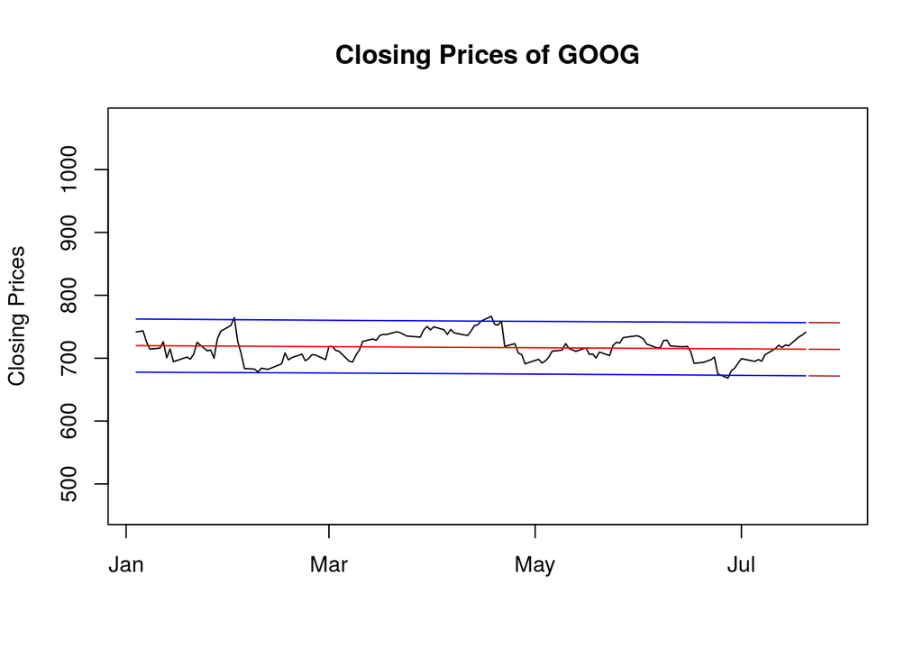

```r
# actual data
plot(type='l', x=x, y=y, ylab="Closing Prices", xlab="", main="Closing Prices of GOOG", ylim=range(c(max(y, conf.interval[, 'upr'], pred.goog[, 'upr']))), xlim = range(c(min(x), max(newdata$x))))
# model
lines(x=x, y=model.fit, col="red")
# 95% confidence interval
lines(x=x, y=conf.interval[, 'lwr'], col='blue')
lines(x=x, y=conf.interval[, 'upr'], col='blue')
# prediction
lines(x =newdata$x, y=pred.goog[, 'fit'], col='brown')
# 95% confidence interval for prediction
lines(x=newdata$x, y=pred.goog[, 'lwr'], col='brown')
lines(x=newdata$x, y=pred.goog[, 'upr'], col='brown')
```